# Pandas

Set working directory

```python
import os
import pandas as pd
os.getcwd()
```

```
'C:\\Users\\generalids\\Desktop\\Final_project'
```

```python
os.chdir("C:\\Users\\generalids\\Desktop\\Final_project\\20210222_generali_project_database")

wd = os.getcwd()
print(wd)
```

```
C:\Users\generalids\Desktop\Final_project\20210222_generali_project_database
```

## Importing a database

```python
sales = pd.read_csv(wd + "\\sales_model.csv")
finance = pd.read_csv(wd + "\\finance_model.csv")
crm = pd.read_csv(wd + "\\crm_model.csv")
twitter = pd.read_csv(wd + "\\twitter_model.csv")
```

```python
sales
```

|  | ID_SALES | Program_Code | From_Grade | To_Grade | Group_State | Days | Travel_Type | Departure_Date | Return_Date | Early_RPL | ... | SPR_Product_Type | FPP | Total_Pax | DepartureMonth | GroupGradeTypeLow | GroupGradeTypeHigh | GroupGradeType | MajorProgramCode | FPP_to_School_enrollment | Retained |
| --- | --- | --- | --- | --- | --- | --- | --- | --- | --- | --- | --- | --- | --- | --- | --- | --- | --- | --- | --- | --- | --- |
| 0 | CC1387A | CC | 10.0 | 10.0 | CA | 24 | A | 04/07/2019 | 05/01/2019 | 05/11/2018 | ... | East Coast | 26 | 29 | January | K | High | K->High | C | 0,126429354314411 | 1 |
| 1 | CC139A | CC | 5.0 | 6.0 | CA | 18 | A | 04/30/2019 | 05/18/2019 | 03/05/2018 | ... | East Coast | 21 | 22 | January | PK | Middle | PK->Middle | C | 0,173405156631824 | 0 |
| 2 | CC1600A | CC | 7.0 | 7.0 | OR | 13 | A | 03/17/2019 | 03/30/2019 | NaN | ... | East Coast | 7 | 7 | January | K | Middle | K->Middle | C | 0,108985714542943 | 1 |
| 3 | CC1701A | CC | 8.0 | 8.0 | CA | 24 | A | 05/08/2019 | 06/01/2019 | 02/07/2018 | ... | East Coast | 26 | 25 | January | PK | Middle | PK->Middle | C | 0,142807017036153 | 1 |
| 4 | CC1773A | CC | 7.0 | 7.0 | OR | 13 | A | 03/17/2019 | 03/30/2019 | NaN | ... | East Coast | 7 | 7 | January | K | Middle | K->Middle | C | 0,108985714542943 | 1 |
| ... | ... | ... | ... | ... | ... | ... | ... | ... | ... | ... | ... | ... | ... | ... | ... | ... | ... | ... | ... | ... | ... |
| 4148 | ST60A | ST | 7.0 | 9.0 | WA | 18 | A | 04/04/2019 | 04/22/2019 | 03/17/2018 | ... | Science | 12 | 11 | January | Middle | High | Middle->High | S | 0,014665665548888 | 0 |
| 4149 | ST809A | ST | 6.0 | 8.0 | WA | 13 | A | 03/21/2019 | 04/03/2019 | 03/05/2018 | ... | Science | 13 | 17 | January | Elementary | Middle | Elementary->Middle | S | 0,01776427530478 | 1 |
| 4150 | ST925A | ST | 8.0 | 12.0 | NJ | 20 | A | 04/16/2019 | 05/06/2019 | 01/21/2018 | ... | Science | 4 | 6 | January | Middle | Middle | Middle->Middle | S | 0,006920828413484 | 0 |
| 4151 | ST928A | ST | 7.0 | 8.0 | OK | 10 | A | 06/01/2019 | 06/11/2019 | 03/09/2018 | ... | Science | 10 | 12 | January | Middle | Middle | Middle->Middle | S | 0,009419789252674 | 1 |
| 4152 | ST960A | ST | 10.0 | 13.0 | ND | 15 | A | 05/29/2019 | 06/13/2019 | 03/08/2018 | ... | Science | 3 | 4 | January | K | High | K->High | S | 0,008308224105284 | 0 |

4153 rows × 24 columns

We import the cleaned and merged dataset.

```python
clean_data = pd.read_csv("C:\\Users\\generalids\\Desktop\\Final_project\\clean_model.csv")
```

We check the shapes of datasets

```python
print ("Sales shape: {0}".format(sales.shape))
print ("Finance shape: {0}".format(finance.shape))
print("CRM shape: {0}".format(crm.shape))
print("Twitter shape: {0}".format(twitter.shape))
print("Clean shape: {0}".format(clean_data.shape))
```

```
Sales shape: (4153, 24)
Finance shape: (4151, 12)
CRM shape: (4148, 20)
Twitter shape: (12706, 2)
Clean shape: (3095, 49)
```

We can see that the clean dataset is smaller. Maybe some IDs are missing in the merged dataset as the join made was and inner join.

We check the datatypes of the data.

```python
clean_data.dtypes
```

```
Unnamed: 0                          int64
Program_Code                       object
From_Grade                        float64
To_Grade                          float64
Group_State                        object
Days                                int64
Travel_Type                        object
Departure_Date                     object
Return_Date                        object
Cancelled_Pax                       int64
Total_Discount_Pax                  int64
SPR_Product_Type                   object
FPP                                 int64
Total_Pax                           int64
DepartureMonth                     object
GroupGradeTypeLow                  object
GroupGradeTypeHigh                 object
GroupGradeType                     object
MajorProgramCode                   object
FPP_to_School_enrollment          float64
Retained                            int64
ID                                  int64
Deposit_Date                       object
Tuition                             int64
FRP_Active                          int64
FRP_Cancelled                       int64
FRP_Take_up_percent_              float64
EZ_Pay_Take_Up_Rate               float64
School_Sponsor                      int64
SPR_Group_Revenue                   int64
FPP_to_PAX                        float64
Num_of_Non_FPP_PAX                  int64
Poverty_Code                       object
Region                             object
CRM_Segment                       float64
School_Type                        object
Parent_Meeting_Flag                 int64
MDR_Low_Grade                      object
MDR_High_Grade                    float64
Total_School_Enrollment             int64
Income_Level                       object
SPR_New_Existing                    int64
NumberOfMeetingswithParents         int64
DifferenceTraveltoFirstMeeting    float64
DifferenceTraveltoLastMeeting     float64
SchoolGradeTypeLow                 object
SchoolGradeTypeHigh                object
SchoolGradeType                    object
SchoolSizeIndicator                object
dtype: object
```

```python
clean_data
```

|  | Unnamed: 0 | Program_Code | From_Grade | To_Grade | Group_State | Days | Travel_Type | Departure_Date | Return_Date | Cancelled_Pax | ... | Total_School_Enrollment | Income_Level | SPR_New_Existing | NumberOfMeetingswithParents | DifferenceTraveltoFirstMeeting | DifferenceTraveltoLastMeeting | SchoolGradeTypeLow | SchoolGradeTypeHigh | SchoolGradeType | SchoolSizeIndicator |
| --- | --- | --- | --- | --- | --- | --- | --- | --- | --- | --- | --- | --- | --- | --- | --- | --- | --- | --- | --- | --- | --- |
| 0 | 0 | HC | 5.0 | 6.0 | CA | 27 | A | 2019-04-13 | 2019-05-10 | 5 | ... | 705 | K | 1 | 1 | 222.0 | 216.0 | Middle | Middle | Middle->Middle | M-L |
| 1 | 1 | HC | 9.0 | 9.0 | TX | 22 | A | 2019-06-09 | 2019-07-01 | 5 | ... | 856 | L | 0 | 1 | 251.0 | 248.0 | Middle | Middle | Middle->Middle | L |
| 2 | 2 | HC | 10.0 | 10.0 | TX | 14 | A | 2019-06-09 | 2019-06-23 | 7 | ... | 730 | I | 1 | 2 | 438.0 | 247.0 | Middle | Middle | Middle->Middle | M-L |
| 3 | 3 | HC | 8.0 | 8.0 | IL | 12 | A | 2019-03-28 | 2019-04-09 | 3 | ... | 398 | M | 1 | 1 | 183.0 | 171.0 | Middle | Middle | Middle->Middle | S-M |
| 4 | 4 | HC | 7.0 | 8.0 | CA | 18 | A | 2019-06-13 | 2019-07-01 | 4 | ... | 951 | O | 1 | 2 | 377.0 | 242.0 | Middle | Middle | Middle->Middle | L |
| ... | ... | ... | ... | ... | ... | ... | ... | ... | ... | ... | ... | ... | ... | ... | ... | ... | ... | ... | ... | ... | ... |
| 3090 | 3090 | ST | 7.0 | 9.0 | WA | 18 | A | 2019-04-04 | 2019-04-22 | 2 | ... | 644 | O | 0 | 1 | 191.0 | 187.0 | Middle | High | Middle->High | M-L |
| 3091 | 3091 | ST | 6.0 | 8.0 | WA | 13 | A | 2019-03-21 | 2019-04-03 | 3 | ... | 908 | M | 0 | 1 | 188.0 | 191.0 | Middle | Middle | Middle->Middle | L |
| 3092 | 3092 | ST | 8.0 | 12.0 | NJ | 20 | A | 2019-04-16 | 2019-05-06 | 2 | ... | 553 | N | 0 | 1 | 201.0 | 208.0 | Middle | High | Middle->High | S-M |
| 3093 | 3093 | ST | 7.0 | 8.0 | OK | 10 | A | 2019-06-01 | 2019-06-11 | 2 | ... | 1257 | I | 0 | 1 | 254.0 | 269.0 | Middle | Middle | Middle->Middle | L |
| 3094 | 3094 | ST | 10.0 | 13.0 | ND | 15 | A | 2019-05-29 | 2019-06-13 | 5 | ... | 363 | N | 0 | 2 | 366.0 | 267.0 | High | High | High->High | S-M |

3095 rows × 49 columns

```python
# Transform dates in date format

clean_data[['Departure_Date']] = clean_data[['Departure_Date']].apply(pd.to_datetime)
clean_data[['Return_Date']] = clean_data[['Return_Date']].apply(pd.to_datetime)
clean_data[['Deposit_Date']] = clean_data[['Deposit_Date']].apply(pd.to_datetime)
```

# Check each atribute

We check each attribute and do some analysis

Retained: target variable

```python
import numpy as np
from matplotlib import pyplot
```

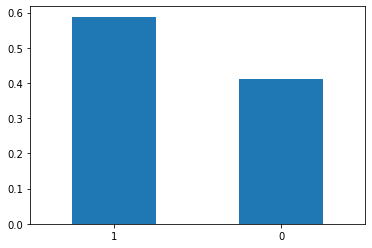

```python
nr_obs = clean_data.shape[0]
val_perc = clean_data['Retained'].value_counts()/clean_data.shape[0]
val_perc.plot.bar(rot = 0)
```

# Program code

categorical variable Most observations in first two classes. Looks loke category of the trip.

```python
Program_code_count = clean_data['Program_Code'].value_counts()
print(Program_code_count)
```

```
HD     1978
HC      420
HN      118
HS      118
SK      105
HVP      92
SC       65
ST       39
SM       34
SG       28
IC       17
HG       11
HY       11
HO       10
HIS       7
HW        7
HF        7
IK        6
SD        6
HH        6
HZ        4
HX        4
HP        2
Name: Program_Code, dtype: int64
```

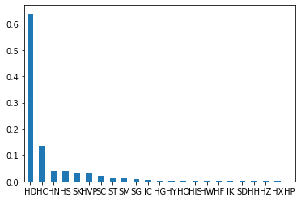

```python
(Program_code_count/nr_obs).plot.bar(rot=0)
```

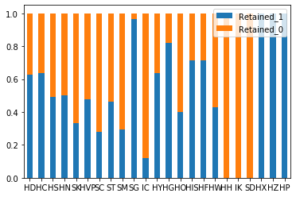

```python
program_code_0 = clean_data.loc[clean_data['Retained'] == 0, 'Program_Code' ].value_counts()/Program_code_count
program_code_1 = clean_data.loc[clean_data['Retained'] == 1, 'Program_Code' ].value_counts()/Program_code_count

df = pd.DataFrame({'Retained_0': program_code_0,
                   'Retained_1': program_code_1,
                   'Count' : Program_code_count})
ax = df.sort_values(by='Count',ascending=False)
#(clean_data['Program_Code'].value_counts()/nr_obs).plot.bar(rot=0)


#ax[['Retained_1', 'Retained_0']].plot.bar(rot=0)
ax[['Retained_1', 'Retained_0']].plot.bar(rot=0, stacked = True)
```

# Createing a function for easy plot of categorical variables

```python
def cat_variable_plot(p_var_name, p_data):
    nr_obs = p_data.shape[0]
    var_count = p_data[p_var_name].value_counts()
    print(var_count)
    #first barplot
    (var_count/nr_obs).plot.bar(rot = 0, figsize = (15,7.5))

    #second barplot
    ret_0 = p_data.loc[p_data['Retained'] == 0, p_var_name ].value_counts()/var_count
    ret_1 = p_data.loc[p_data['Retained'] == 1, p_var_name ].value_counts()/var_count

    df = pd.DataFrame({'Retained_0': ret_0,
                   'Retained_1': ret_1,
                   'Count' : var_count})
    ax = df.sort_values(by='Count',ascending=False)

    ax[['Retained_1', 'Retained_0']].plot.bar(rot=0, stacked = True, figsize = (15,7.5))
```

# From grade

Categorical variable - "Lowest grade in school of a participant"

```
7.0     700
6.0     574
8.0     518
9.0     487
10.0    312
5.0     246
4.0     100
3.0      56
11.0     31
2.0      30
12.0     30
13.0      8
14.0      2
1.0       1
Name: From_Grade, dtype: int64
```

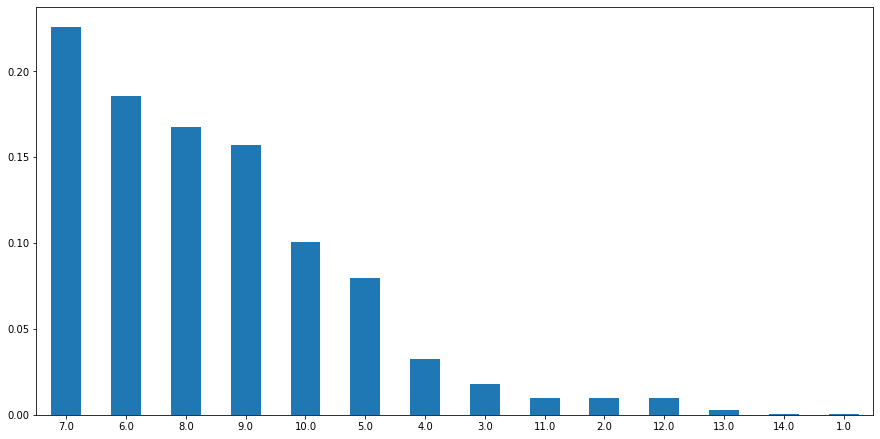

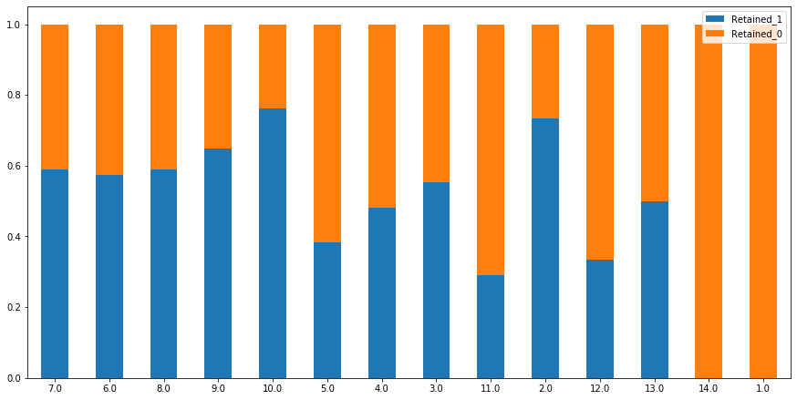

```python
cat_variable_plot('From_Grade', clean_data)
```

# To grade

"Highest grade in school of partiicipant" - could be interesting to look at difference between from and to grade

```
8.0     709
7.0     525
9.0     504
10.0    500
6.0     498
11.0     70
12.0     63
5.0      57
4.0      44
3.0      43
13.0     35
14.0     25
2.0      22
Name: To_Grade, dtype: int64
```

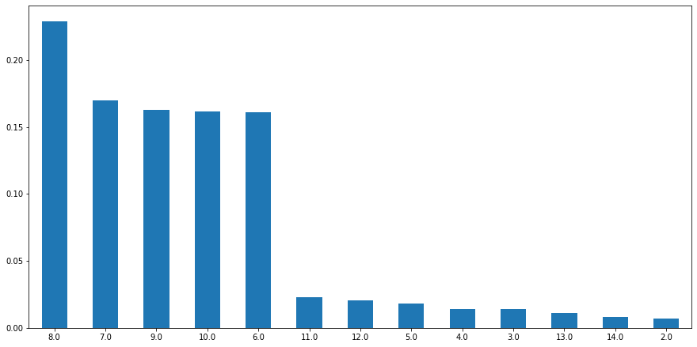

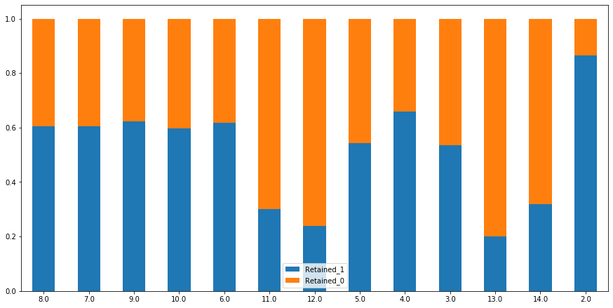

```python
cat_variable_plot('To_Grade', clean_data)
```

# Group_State

"school location"

```
CA    775
TX    444
WA    205
IL    156
CO    138
MI    104
OH     77
FL     71
MO     68
WI     65
OR     64
IN     63
MN     62
IA     61
AZ     59
NE     57
OK     49
TN     46
KS     44
MA     43
AL     38
LA     34
NV     32
NM     28
VA     25
GA     24
MD     23
KY     22
CT     22
NY     20
ID     17
SD     16
UT     13
NC     13
SC     12
NH     11
AR     11
ND     10
NJ     10
MT     10
ME      9
MS      9
AK      8
PA      8
HI      7
RI      6
WY      4
VT      2
Name: Group_State, dtype: int64
```

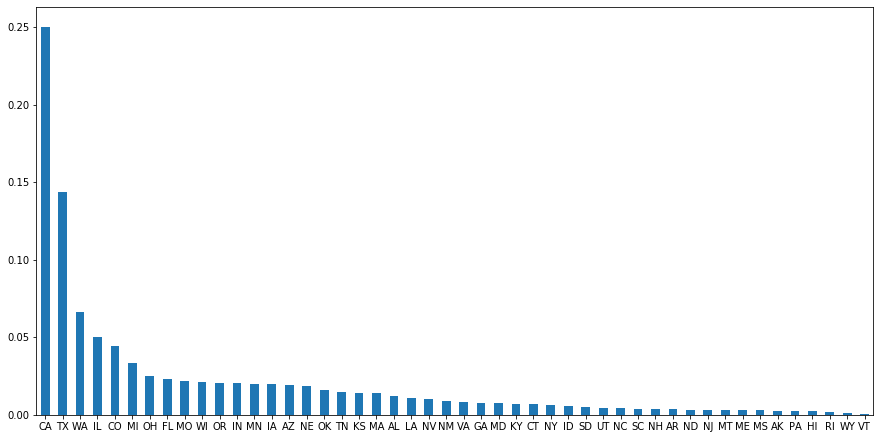

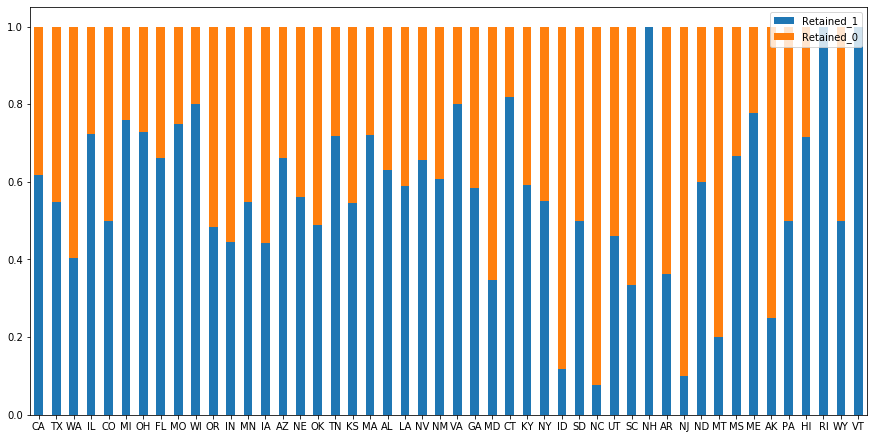

```python
cat_variable_plot('Group_State', clean_data)
```

# Days

"number of days on the program"

```
count    3095.000000
mean       15.214863
std         6.304596
min         1.000000
25%        11.000000
50%        15.000000
75%        19.000000
max        52.000000
Name: Days, dtype: float64
```

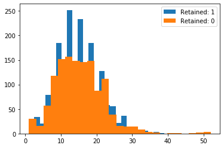

```python
print(clean_data['Days'].describe())


pyplot.hist(clean_data.loc[clean_data['Retained'] == 1, 'Days'], bins = 25, label = 'Retained: 1')
pyplot.hist(clean_data.loc[clean_data['Retained'] == 0, 'Days'], bins = 25, label = 'Retained: 0')
pyplot.legend(loc='upper right')
pyplot.show()
```

# Travel type

"Travel mode (A = Air, B = Bus, T= Train)

```
A    2586
T     502
B       7
Name: Travel_Type, dtype: int64
```

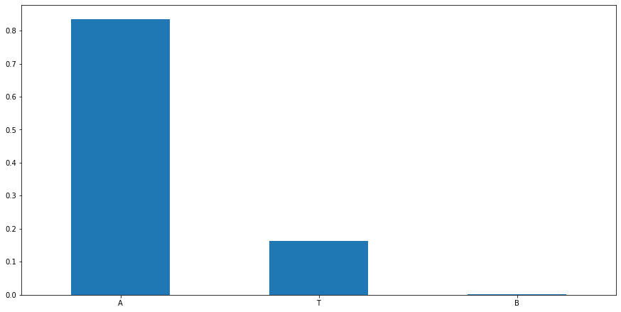

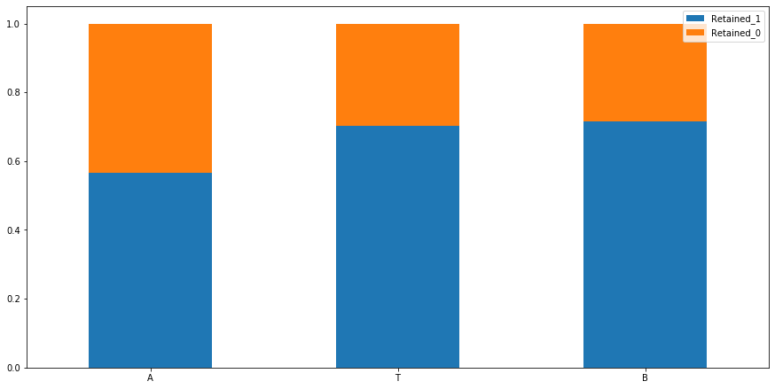

```python
cat_variable_plot('Travel_Type', clean_data)
```

# Departure and return date; Early_RPL, Latest _RPL; Initial system Date

Early rpl: First communication date inviting people to join Latest rpl: Last communication inviting people to join Initial system date: First date when trip was organized

Could be interesting to see the difference between first and last reply and departure date; Early RPL and Latest RPL columns were dropped this may not be OK as NA may mean no communication. Could be a significant variable

```python
print(clean_data['Departure_Date'].describe())
print(clean_data['Return_Date'].describe())
```

```
count                    3095
unique                    150
top       2019-06-08 00:00:00
freq                       85
first     2019-01-07 00:00:00
last      2019-07-01 00:00:00
Name: Departure_Date, dtype: object
count                    3095
unique                    176
top       2019-06-17 00:00:00
freq                       68
first     2019-01-10 00:00:00
last      2019-08-13 00:00:00
Name: Return_Date, dtype: object
```

# Cancelled pax

Number of passengers who made a deposit but cancelled

```
count    3095.000000
mean        5.375767
std         4.927725
min         0.000000
25%         2.000000
50%         4.000000
75%         7.000000
max        44.000000
Name: Cancelled_Pax, dtype: float64
```

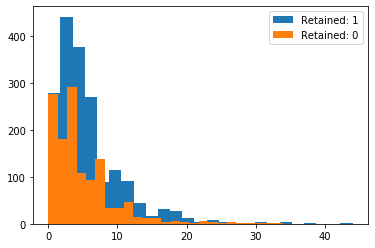

```python
print(clean_data['Cancelled_Pax'].describe())


pyplot.hist(clean_data.loc[clean_data['Retained'] == 1, 'Cancelled_Pax'], bins = 25, label = 'Retained: 1')
pyplot.hist(clean_data.loc[clean_data['Retained'] == 0, 'Cancelled_Pax'], bins = 25, label = 'Retained: 0')
pyplot.legend(loc='upper right')
pyplot.show()
```

# Total_Discount_Pax

Number of extra passengers (professors)

```
count    3095.000000
mean        3.031987
std         3.217188
min         0.000000
25%         1.000000
50%         2.000000
75%         4.000000
max        53.000000
Name: Total_Discount_Pax, dtype: float64
```

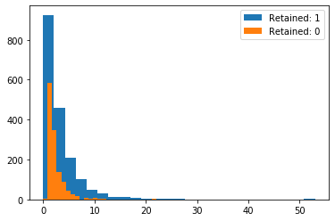

```python
print(clean_data['Total_Discount_Pax'].describe())


pyplot.hist(clean_data.loc[clean_data['Retained'] == 1, 'Total_Discount_Pax'], bins = 25, label = 'Retained: 1')
pyplot.hist(clean_data.loc[clean_data['Retained'] == 0, 'Total_Discount_Pax'], bins = 25, label = 'Retained: 0')
pyplot.legend(loc='upper right')
pyplot.show()
```

# SPR_Product_Type

Aggregation of tour types

```
East Coast       2642
Science           212
CA History        146
Costa Rica         65
International      23
IL History          7
Name: SPR_Product_Type, dtype: int64
```

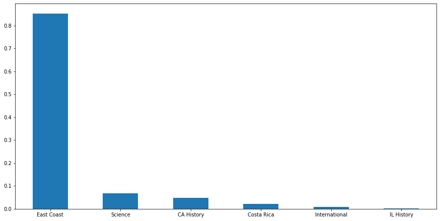

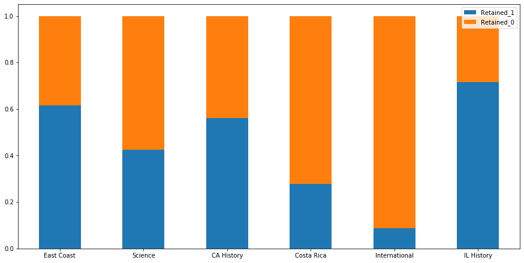

```python
cat_variable_plot('SPR_Product_Type', clean_data)
```

# FPP

Number of full-payment participant

```
count    3095.000000
mean       30.848142
std        31.385877
min         2.000000
25%        11.000000
50%        21.000000
75%        40.000000
max       296.000000
Name: FPP, dtype: float64
```

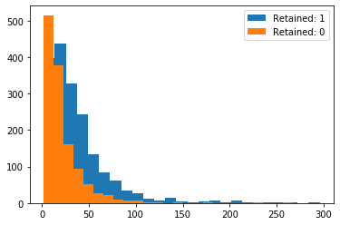

```python
print(clean_data['FPP'].describe())


pyplot.hist(clean_data.loc[clean_data['Retained'] == 1, 'FPP'], bins = 25, label = 'Retained: 1')
pyplot.hist(clean_data.loc[clean_data['Retained'] == 0, 'FPP'], bins = 25, label = 'Retained: 0')
pyplot.legend(loc='upper right')
pyplot.show()
```

# Total PAX

Number of total passengers

```
count    3095.000000
mean       33.948304
std        34.118684
min         2.000000
25%        13.000000
50%        24.000000
75%        44.000000
max       320.000000
Name: Total_Pax, dtype: float64
```

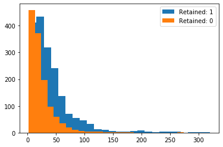

```python
print(clean_data['Total_Pax'].describe())


pyplot.hist(clean_data.loc[clean_data['Retained'] == 1, 'Total_Pax'], bins = 25, label = 'Retained: 1')
pyplot.hist(clean_data.loc[clean_data['Retained'] == 0, 'Total_Pax'], bins = 25, label = 'Retained: 0')
pyplot.legend(loc='upper right')
pyplot.show()
```

# Departure month

Looks like we need to fix this column

```
January     3086
December       9
Name: DepartureMonth, dtype: int64
```

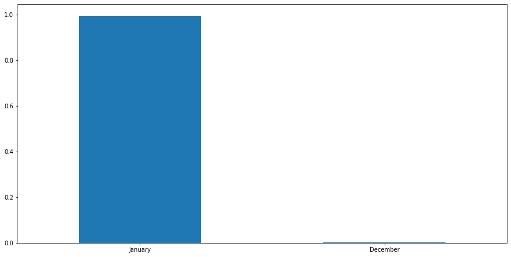

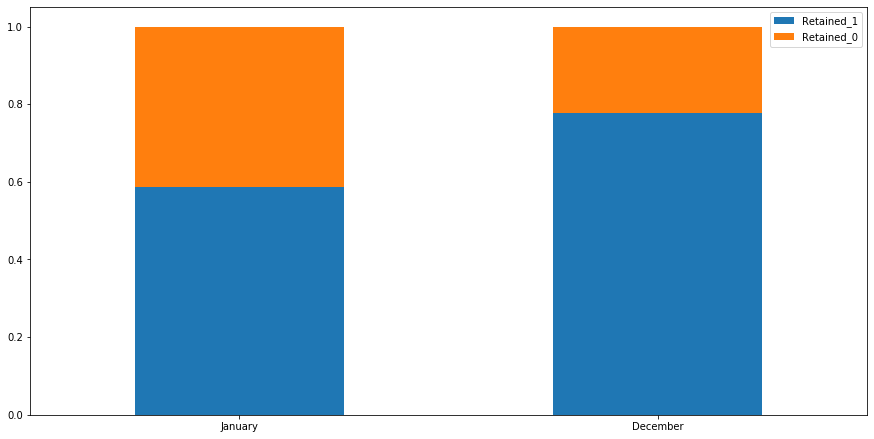

```python
cat_variable_plot('DepartureMonth', clean_data)
```

# Group grade type low; Group grade type high

Lowest and highest grade type in the trip

```
Middle        2080
K              459
Elementary     220
High           170
PK             166
Name: GroupGradeTypeLow, dtype: int64
```

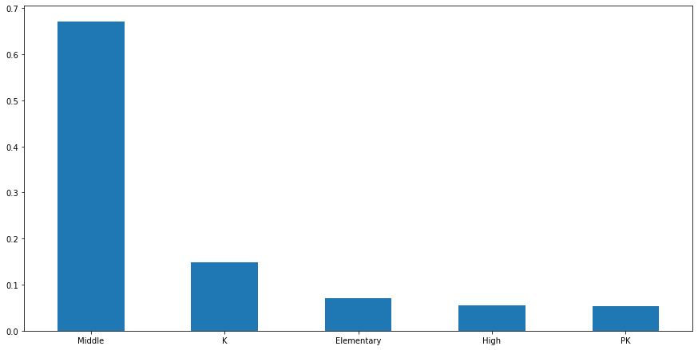

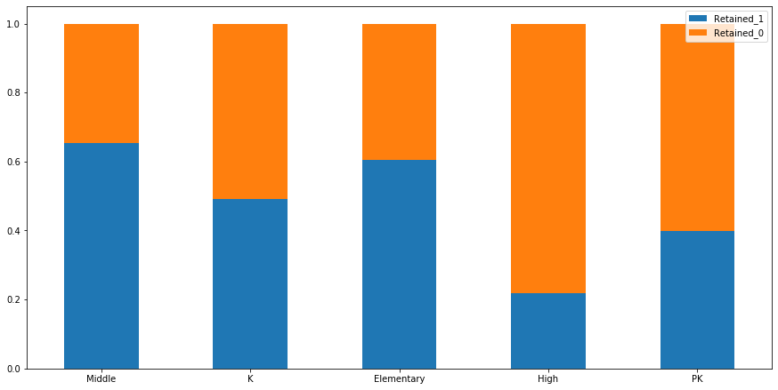

```python
cat_variable_plot('GroupGradeTypeLow', clean_data)
```

```
Middle        2469
High           453
Elementary     173
Name: GroupGradeTypeHigh, dtype: int64
```

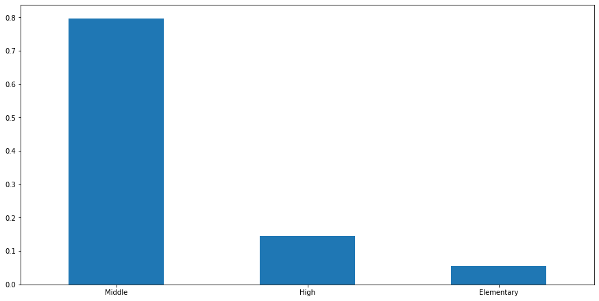

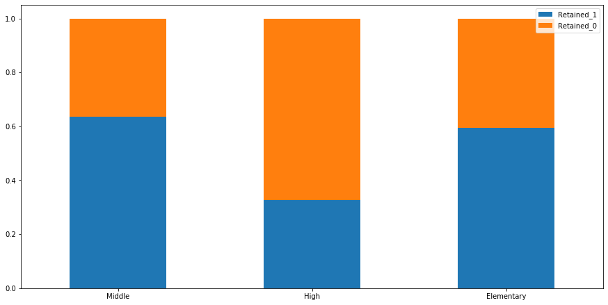

```python
cat_variable_plot('GroupGradeTypeHigh', clean_data)
```

# Group grade type

Combination of the above

```
Middle->Middle            1876
K->Middle                  303
Middle->High               204
Elementary->Middle         197
High->High                 170
K->Elementary              123
PK->Middle                  93
PK->Elementary              38
PK->High                    35
K->High                     33
Elementary->Elementary      12
Elementary->High            11
Name: GroupGradeType, dtype: int64
```

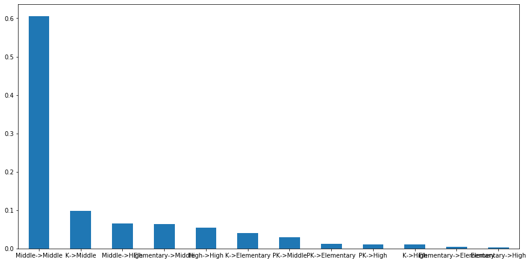

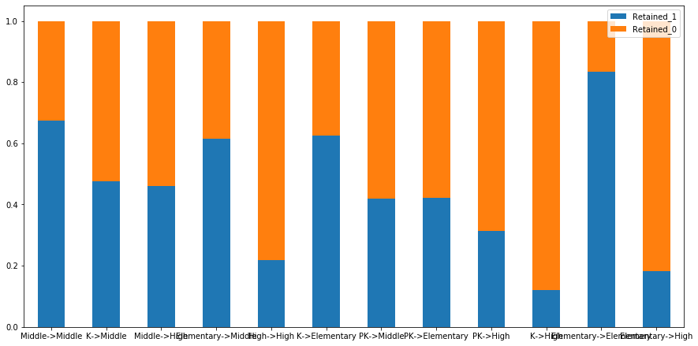

```python
cat_variable_plot('GroupGradeType', clean_data)
```

# Major program code

Agregation of program codes

```
H    2795
S     277
I      23
Name: MajorProgramCode, dtype: int64
```

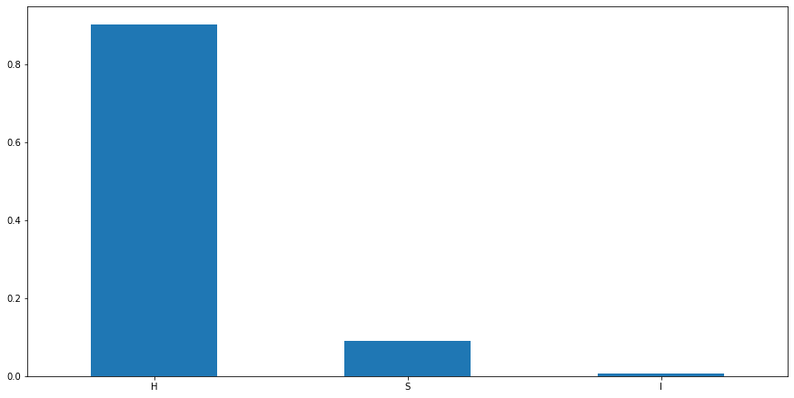

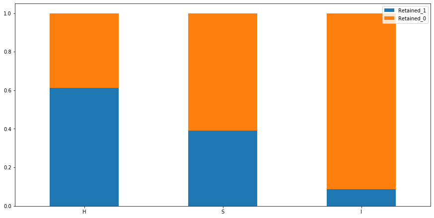

```python
cat_variable_plot('MajorProgramCode', clean_data)
```